fossil

# CoLP, dug back up.

CoLP mapped where proteins sit in normal brain and in glioma, and which ones move. Its server is gone and its code was never released. We rebuilt it from the paper and its 2008 method paper, reran it on the archived data, and checked 35 results on 2026-11-18: 7 agree, 8 partly agree, 11 differ and 9 were not attempted.

See every result

## Install condloc

Python package

```
pip install "git+https://github.com/jeonglab-bcm/fossil#subdirectory=PMC3730102/package"
```

Python 3.10 or later, with NumPy and SciPy.

[README](https://github.com/jeonglab-bcm/fossil/blob/main/PMC3730102/package/README.md) [Tutorial](https://github.com/jeonglab-bcm/fossil/blob/main/PMC3730102/package/tutorial/TUTORIAL.md)

## Fig. 2A

Share of protein pairs that share a location: all pairs and interacting pairs by the sign of their expression correlation, and random link sets.

Agrees

Published

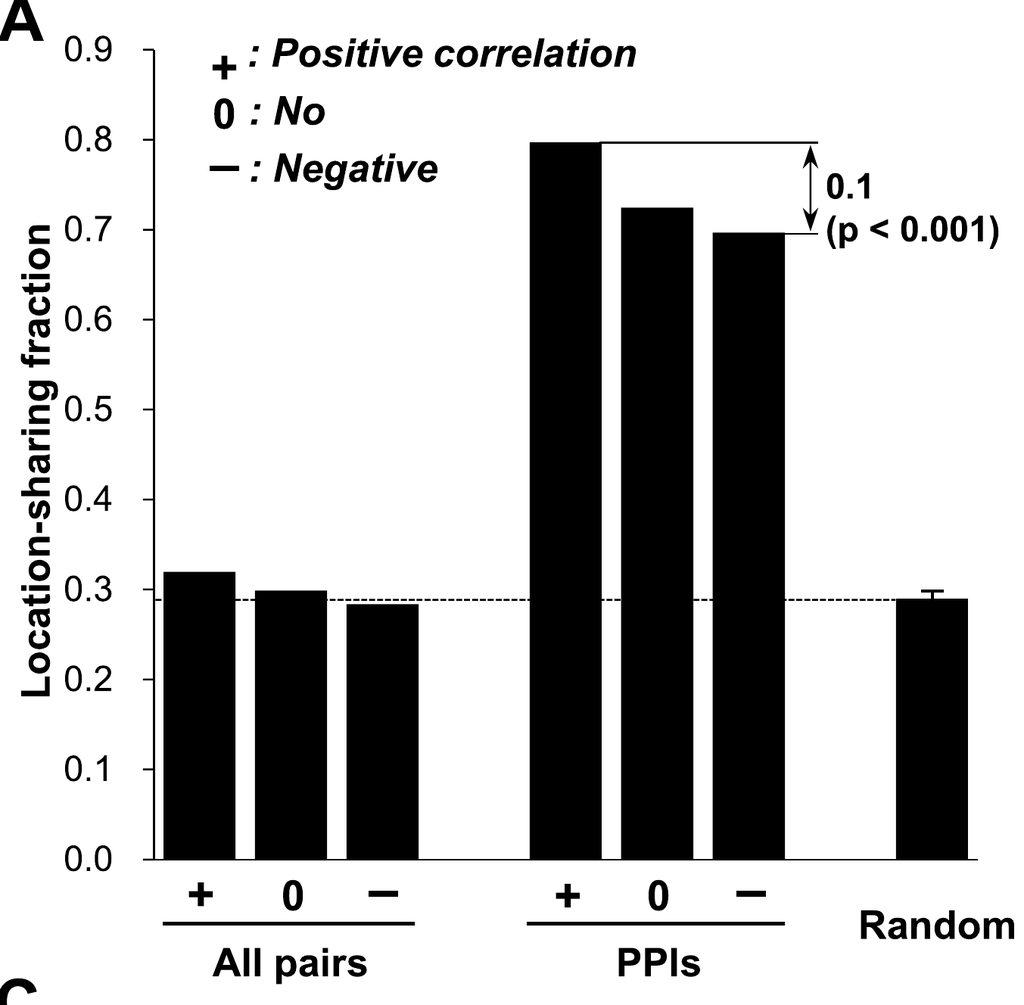

Our run

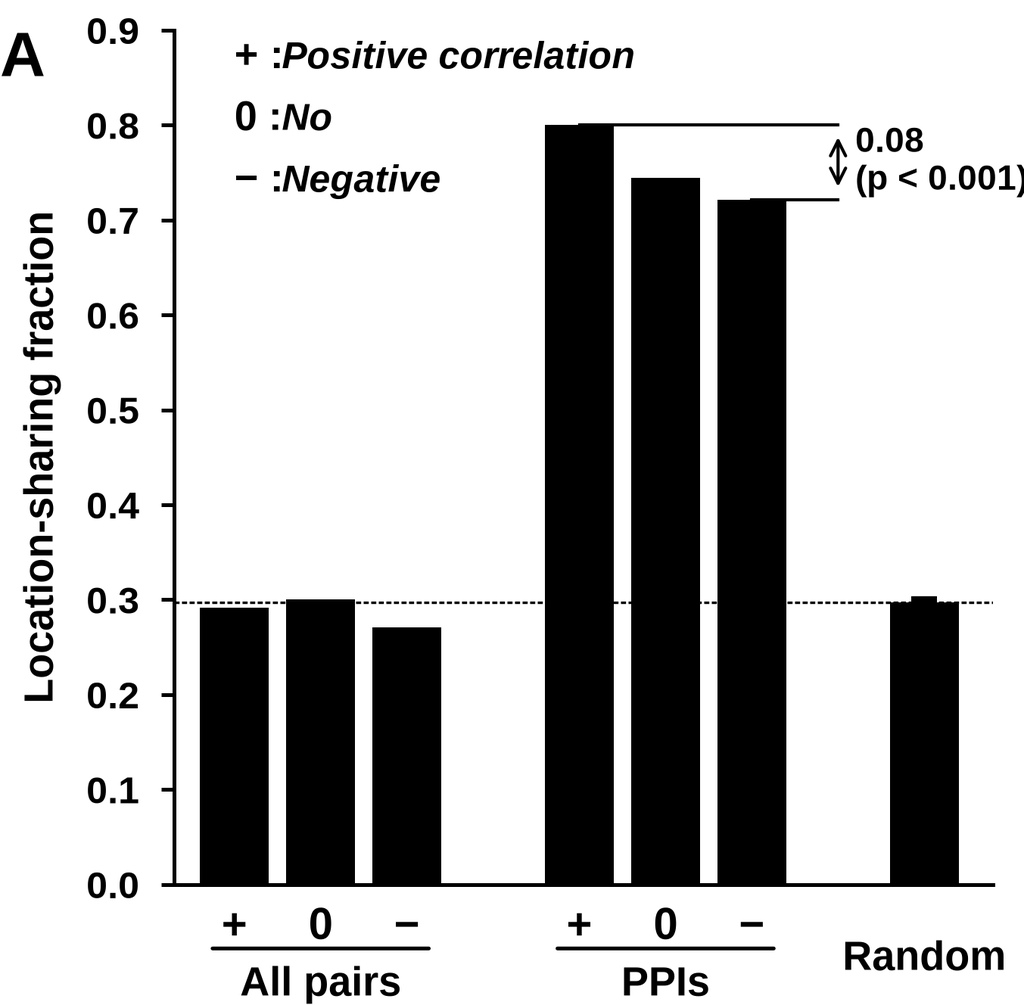

**Fig. 2A, location sharing by expression correlation**

4 of 4 values, Agrees

## Fig. 2B

ROC curves and AUC of DC-kNN with single-protein, physical-link and correlated-pair features (leave-two-out).

Partly agrees

Published

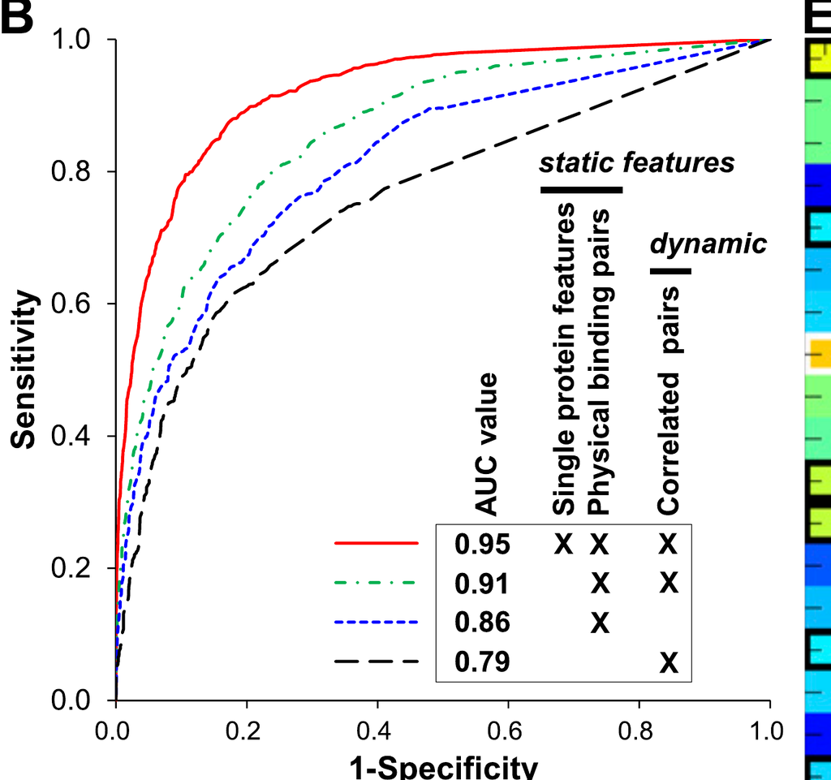

Our run

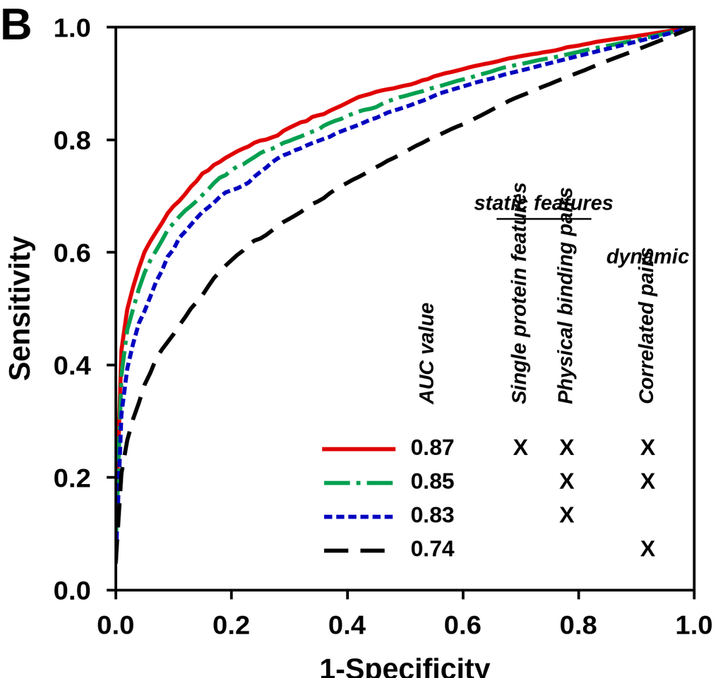

**Fig. 2B, AUC of static and network features**

1 of 5 values, Partly agrees

The four configurations come back in the paper's order, 0.03 to 0.08 lower; the gaps between them differ (ours 0.02, 0.02 and 0.08 against the paper's 0.04, 0.05 and 0.07). The gold standard (4,269 against 4,570 proteins) and the network are rebuilt, and how leave-two-out was run is not stated.

## Fig. 2C

Share of known interactions among the most correlated protein pairs of each condition and among the pairs common to all three.

Differs

Published

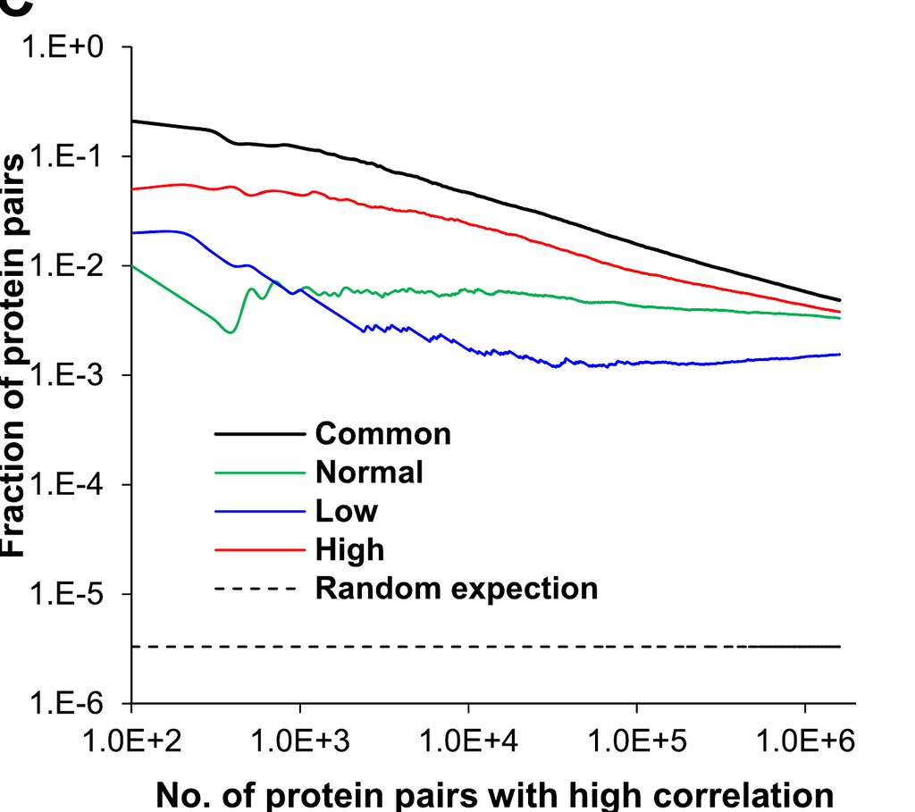

Our run

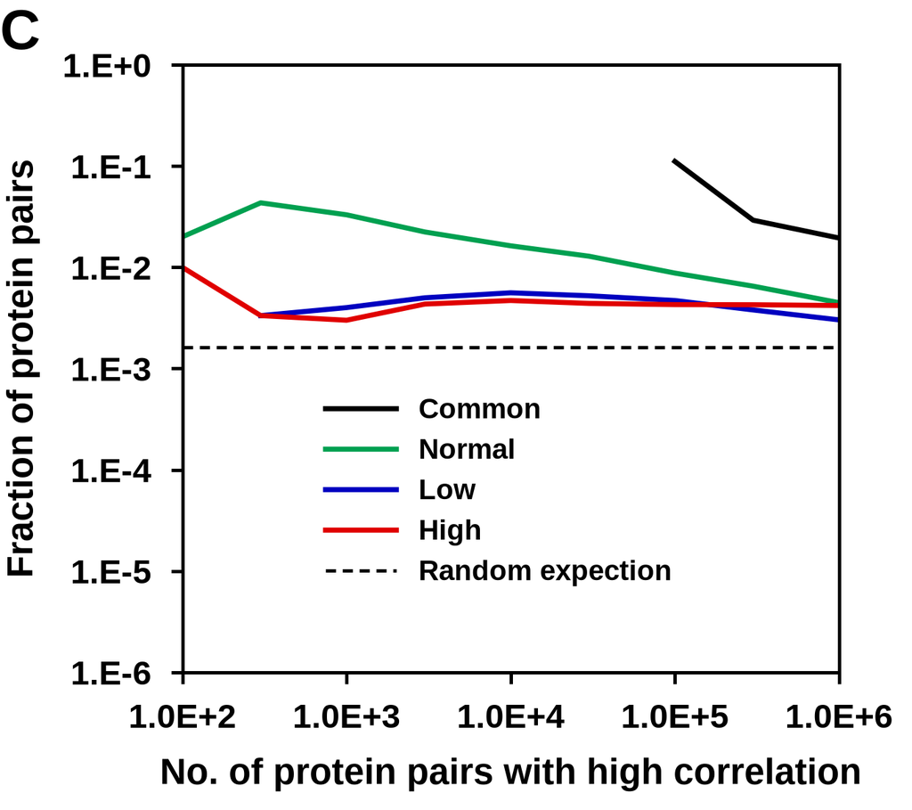

**Fig. 2C, known links among the most correlated pairs**

0 of 2 values, Differs

In normal brain the top 1,000 correlated pairs hold 21 times more known links than chance, as in the paper; in low- and high-grade glioma only 2 times. How the paper pooled several studies of different platforms into one ranking is not stated; our gliomas pool three series on five platforms, two of them small.

## Fig. 2D

Average AUC of each kind of feature set and of the selected models (TR).

Partly agrees

Published

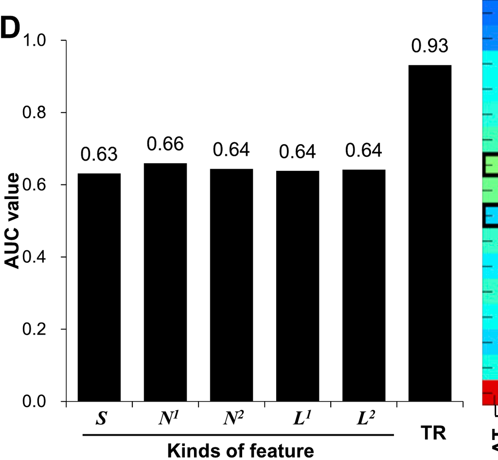

Our run

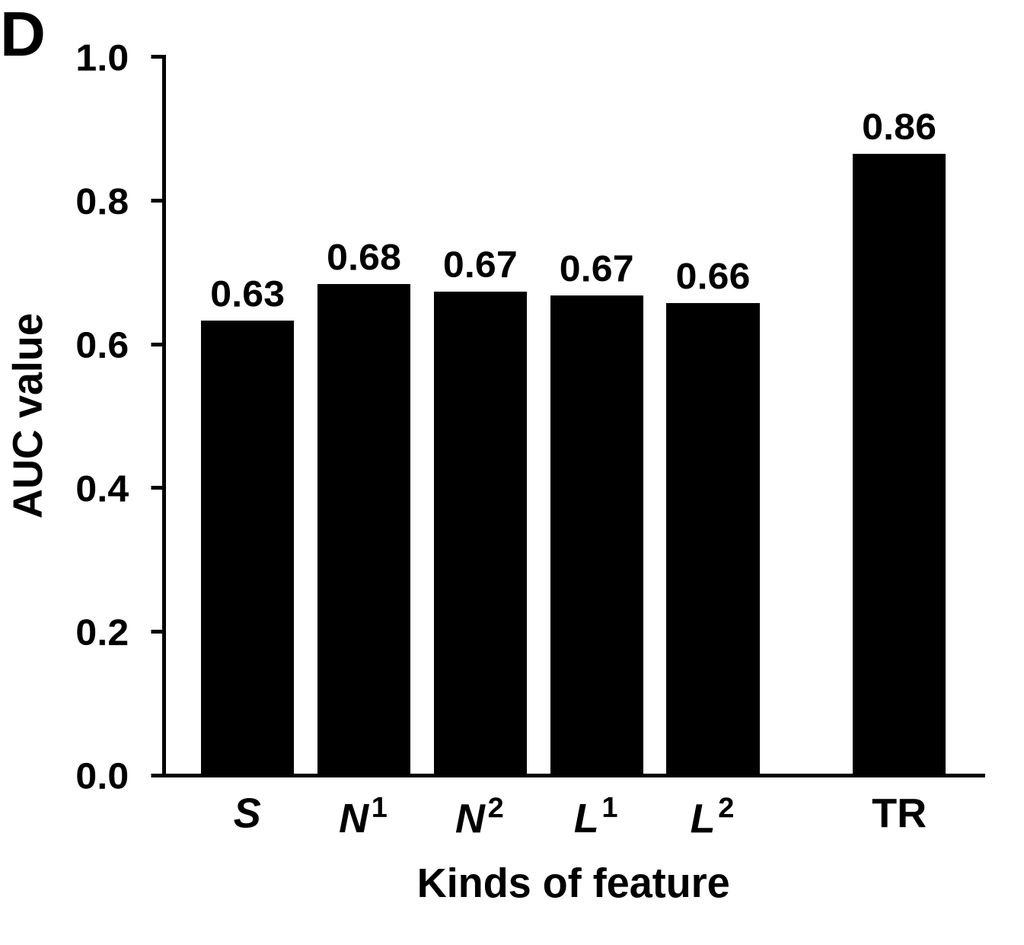

**Fig. 2D, average AUC by kind of feature**

1 of 6 values, Partly agrees

S comes back at 0.63. The network kinds are 0.02 to 0.03 higher (our network and gold standard are rebuilt) and the selected models (TR) are 0.07 lower.

## Fig. 2E

AUC of every feature set for each location; boxes mark the sets chosen by forward selection.

Agrees

Published

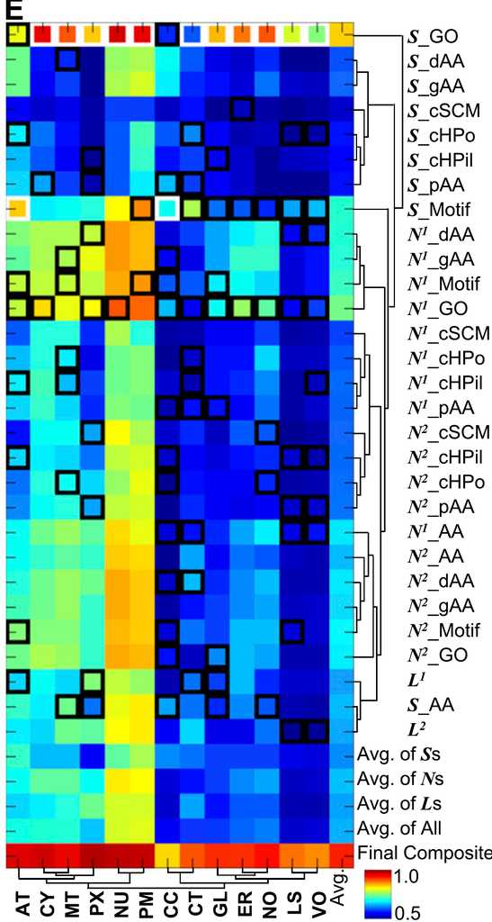

Our run

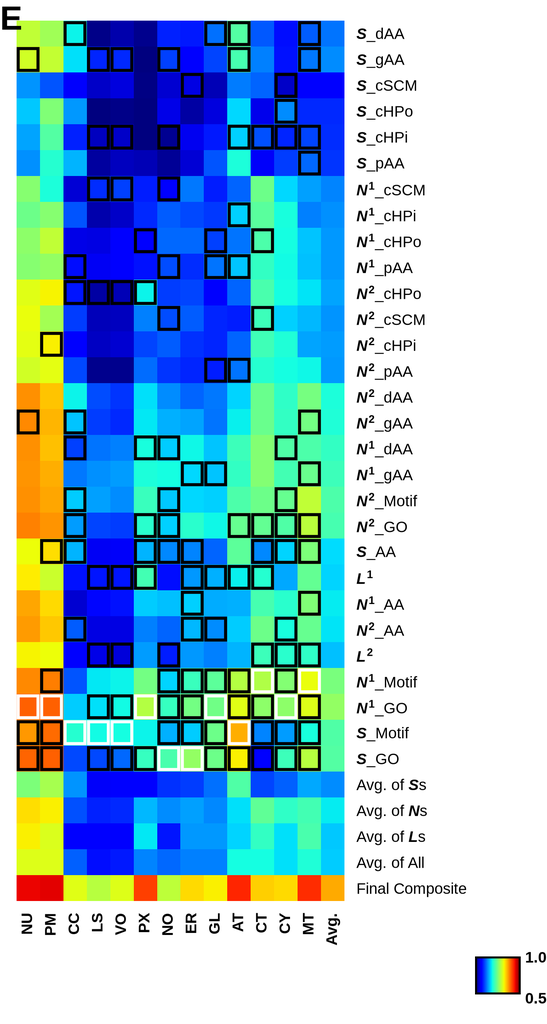

**Fig. 2E, selected feature sets**

2 of 2 values, Agrees

## Fig. 3A

Conditional location map of NKX2-2 in normal brain, low- and high-grade glioma; H marks the top location.

Differs

Published

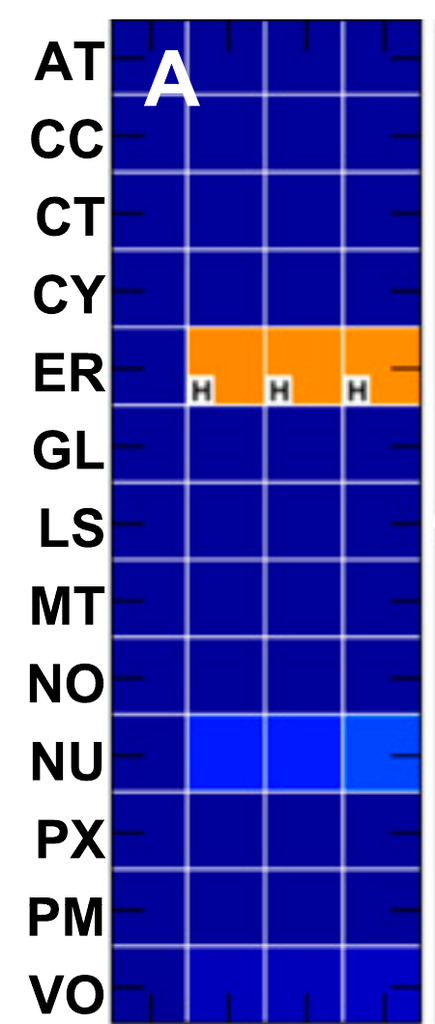

Our run

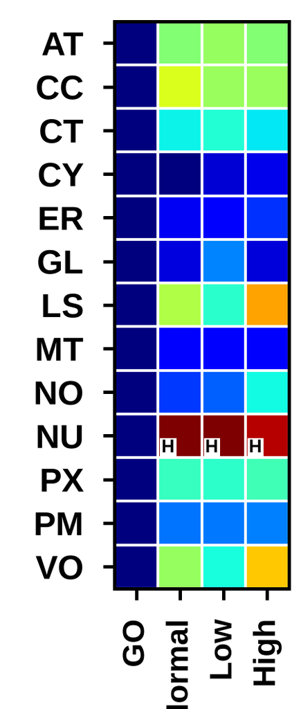

**Fig. 3A, NKX2-2 location map**

0 of 3 values, Differs

The top location of each condition comes from the whole rebuilt chain (gold standard, network, feature sets, coherence weights). Static locations come back more often than condition changes: our condition weights move few maps.

## Fig. 3E

Conditional location map of CPB1.

Differs

Published

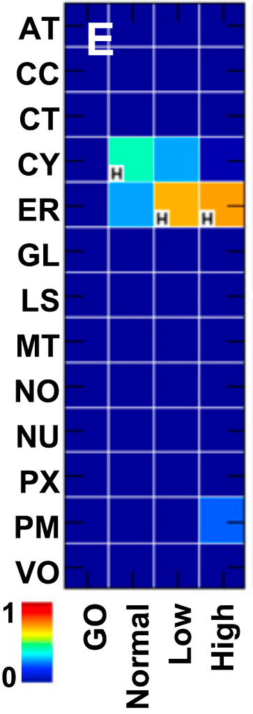

Our run

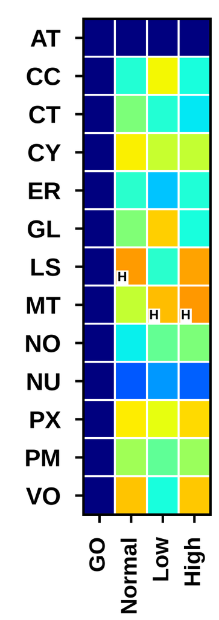

**Fig. 3E, CPB1 location map**

0 of 3 values, Differs

The top location of each condition comes from the whole rebuilt chain (gold standard, network, feature sets, coherence weights). Static locations come back more often than condition changes: our condition weights move few maps.

## Figs 3I and 3J

Predicted possibility of 20 proteins at five locations, with the observed locations (+) of the paper's imaging; boxes are our high-confidence calls.

Differs

Published

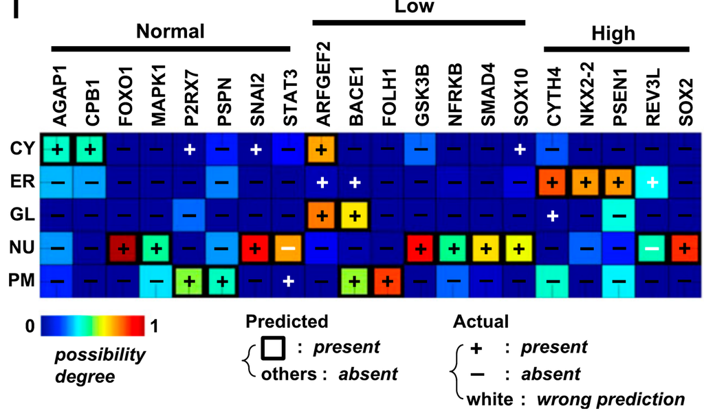

Our run

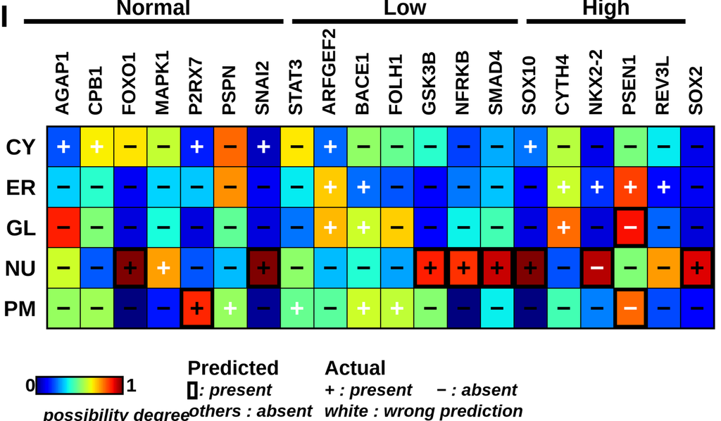

**Figs 3I and 3J, 100 location tests of 20 proteins**

0 of 5 values, Differs

Our maps call fewer locations than the paper's (8 of the 28 observed against 20), so true positives fall and false negatives rise; the true negatives come back.

## Fig. 4A

Conditional location map of KIF13A.

Differs

Published

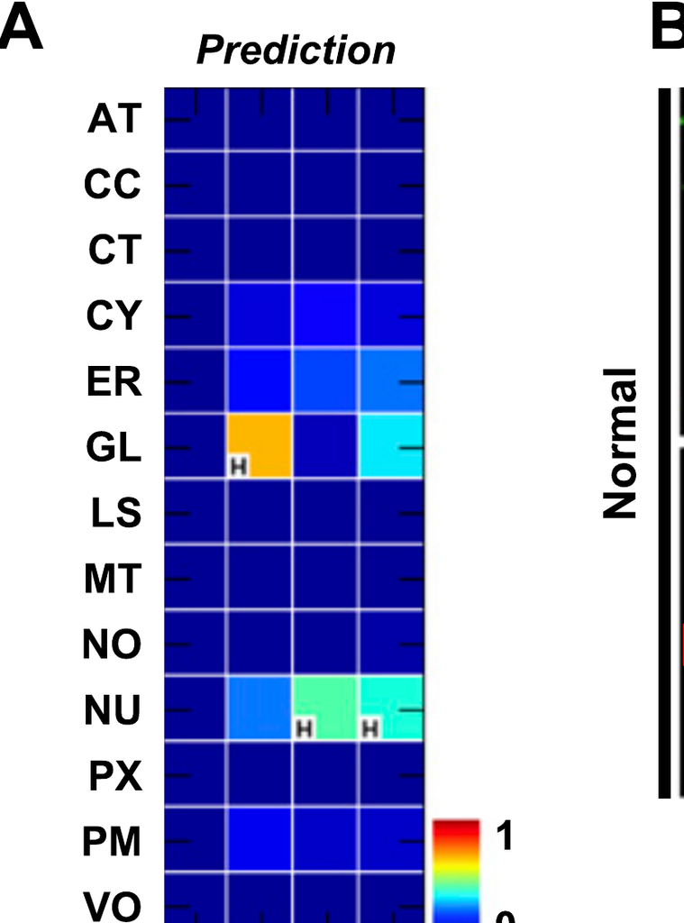

Our run

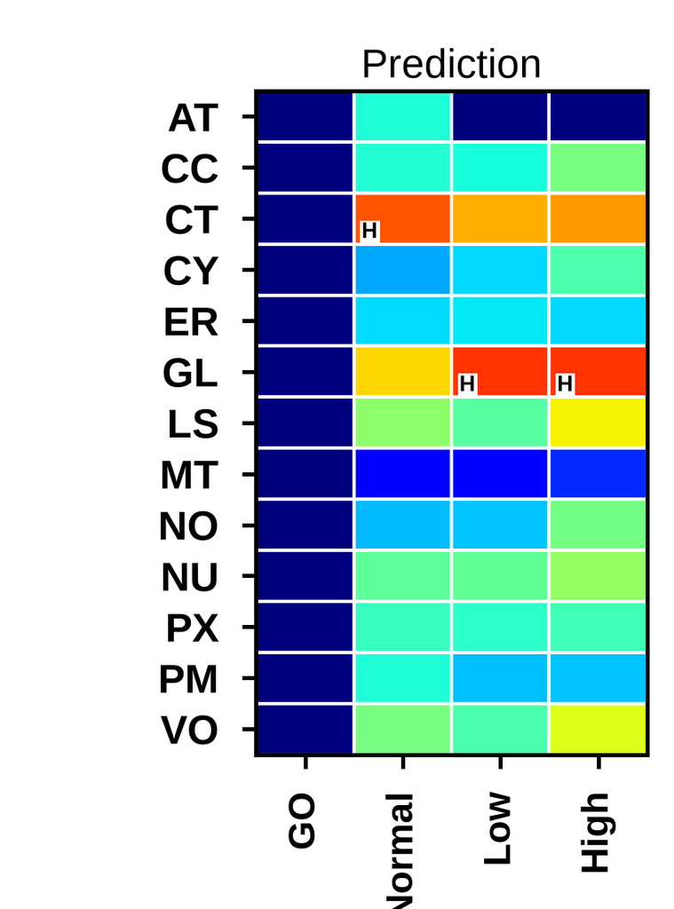

**Fig. 4A, KIF13A location map**

0 of 3 values, Differs

**Figs 4E-G, KIF13A neighbourhood**

0 of 3 values, Differs

The top location of each condition comes from the whole rebuilt chain (gold standard, network, feature sets, coherence weights). Static locations come back more often than condition changes: our condition weights move few maps. KIF13A has 6 links in our network and none to COG2; its AP1G1 link is less coherent in normal brain than in glioma, the reverse of the figure.

## Fig. 5A

Kinds of mislocation from normal brain to glioma, as shares of all mislocations (the paper draws them as a surface).

Differs

Published

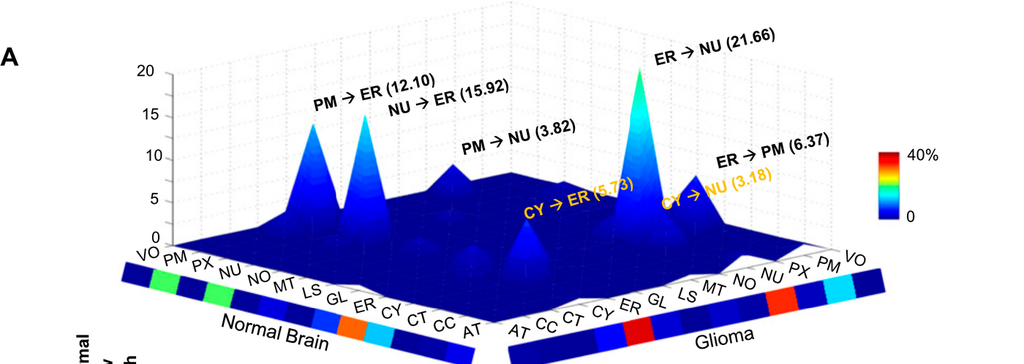

Our run

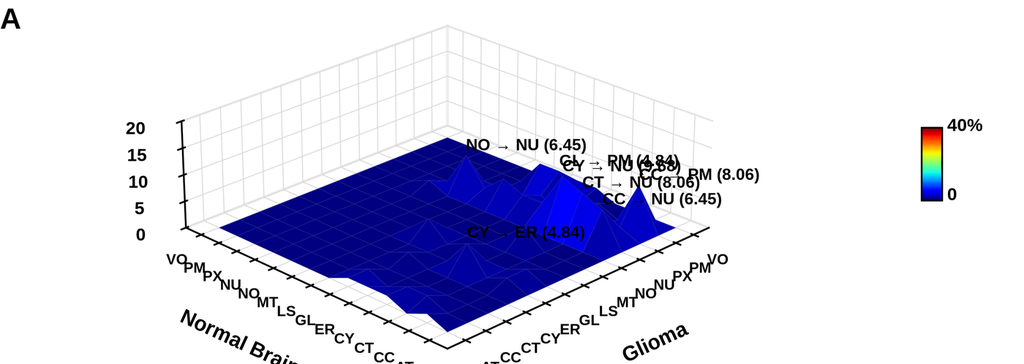

**Fig. 5A, kinds of mislocation**

0 of 7 values, Differs

**Mislocated proteins (text)**

0 of 1 values, Differs

Our mislocations are few and spread over many kinds; the paper's are dominated by moves into and out of the ER, which our maps rarely make. The test behind 'P < 0.01' (Suppl. Fig. S15) is in the unavailable supplement. No version of the rule we tried gives 157.

## Fig. 5B

Conditional location map of RNF138.

Partly agrees

Published

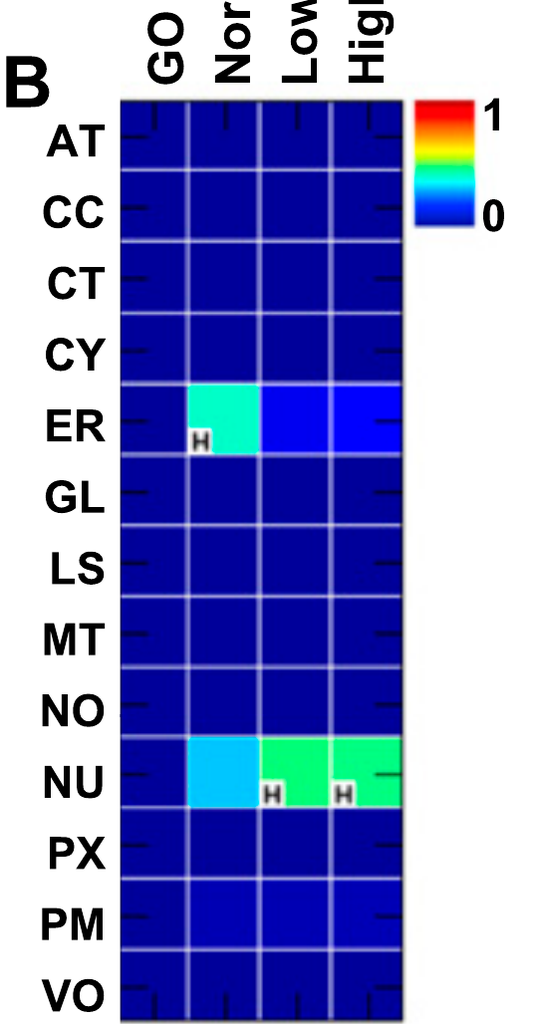

Our run

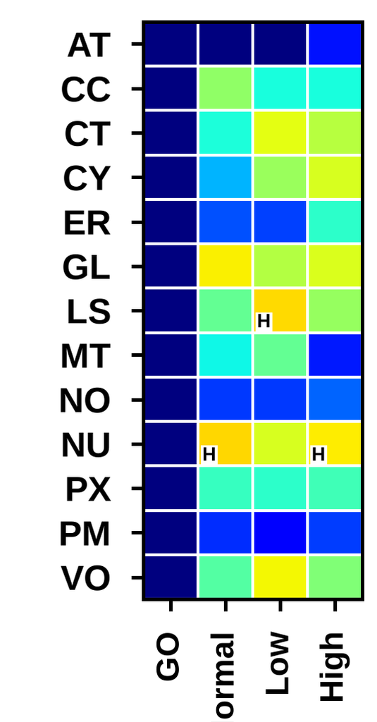

**Fig. 5B, RNF138 location map**

1 of 3 values, Partly agrees

The top location of each condition comes from the whole rebuilt chain (gold standard, network, feature sets, coherence weights). Static locations come back more often than condition changes: our condition weights move few maps.

## Fig. 5C

Conditional location map of TLX3.

Partly agrees

Published

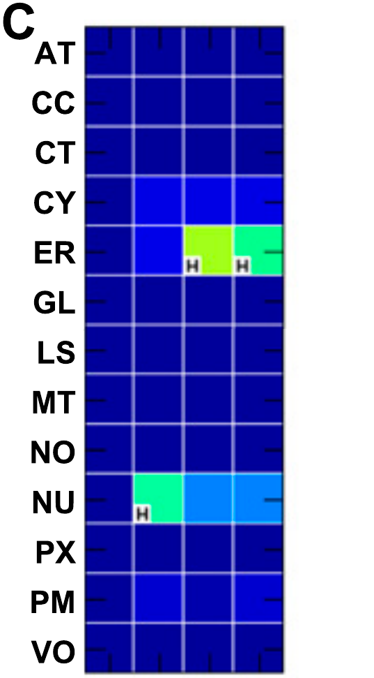

Our run

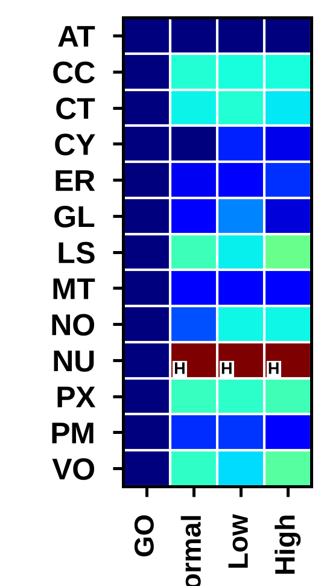

**Fig. 5C, TLX3 location map**

1 of 3 values, Partly agrees

The top location of each condition comes from the whole rebuilt chain (gold standard, network, feature sets, coherence weights). Static locations come back more often than condition changes: our condition weights move few maps.

## Fig. 6A

Conditional location map of GFRA4.

Partly agrees

Published

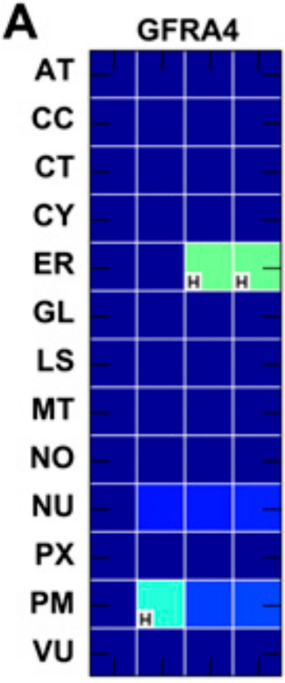

Our run

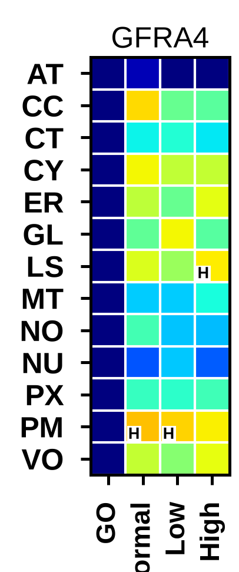

**Fig. 6A, GFRA4 location map**

1 of 3 values, Partly agrees

The top location of each condition comes from the whole rebuilt chain (gold standard, network, feature sets, coherence weights). Static locations come back more often than condition changes: our condition weights move few maps.

## Fig. 6B

Conditional location map of PSPN.

Partly agrees

Published

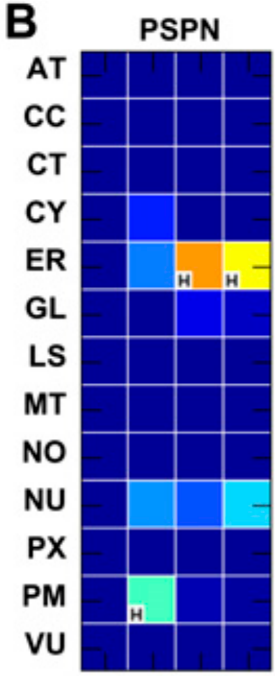

Our run

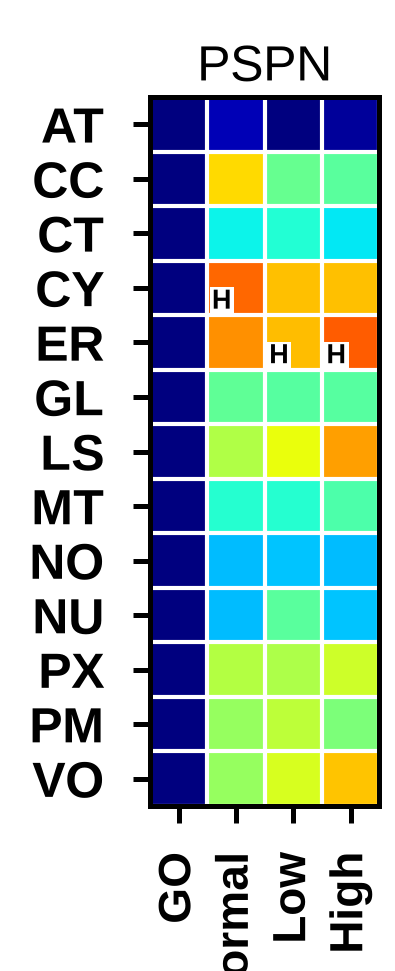

**Fig. 6B, PSPN location map**

2 of 3 values, Partly agrees

The top location of each condition comes from the whole rebuilt chain (gold standard, network, feature sets, coherence weights). Static locations come back more often than condition changes: our condition weights move few maps.

## Fig. 6C

Conditional location map of RET.

Agrees

Published

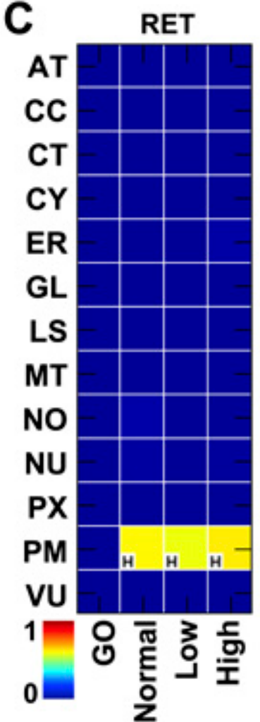

Our run

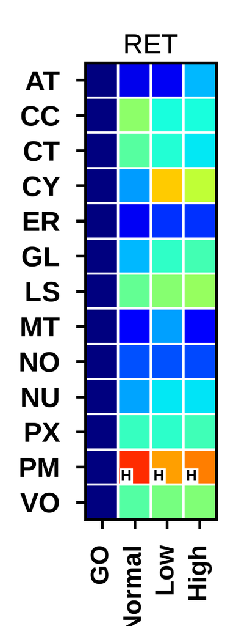

**Fig. 6C, RET location map**

3 of 3 values, Agrees

The top location of each condition comes from the whole rebuilt chain (gold standard, network, feature sets, coherence weights). Static locations come back more often than condition changes: our condition weights move few maps.

## Every result

Every figure, table and number of the paper, with the paper's value and ours. Verdicts are computed from results.json.

Result

Verdict

Measure

Why

Table 1A, static protein features

Not attempted

Lists the sources of the single-protein features; nothing to recompute.

Table 1B, gold-standard locations from GO

Partly agrees

2 of 15 values

- proteins: paper 4570, ours **4269**
- locations: paper 5252, ours **4890**
- AT: paper 155, ours **132**
- CC: paper 41, ours **41**
- CT: paper 56, ours **58**
- CY: paper 308, ours **283**
- ER: paper 432, ours **296**
- GL: paper 222, ours **222**
- LS: paper 76, ours **73**
- MT: paper 419, ours **366**
- NO: paper 128, ours **109**
- NU: paper 1731, ours **1666**
- PX: paper 56, ours **55**
- PM: paper 1543, ours **1507**
- VU: paper 85, ours **82**

The GO release is not stated, and the six experimental codes the Methods name cannot give 4,570 proteins in any release up to 2008. The 4,570 proteins are those of Lee et al. 2008 (Table S3), which come back only from a 2007 release with all non-IEA codes. Mapping 2007 accessions onto current Swiss-Prot then loses about 330 proteins (merged and deleted entries).

Table 1C, pooled interaction network

Differs

0 of 2 values

- interactions: paper 80,970, ours **84309**
- proteins: paper 10,819, ours **10351**

BIND is gone (only its 1,500 links inside Ramani's set survive) and DIP needs a login; the release dates of the other sources are not stated. The rebuilt network is 4% larger in links and 4% smaller in proteins.

Table 1D, expression samples

Agrees

3 of 3 values

- normal: paper 82, ours **82**
- low: paper 23, ours **23**
- high: paper 134, ours **134**

Fig. 1

Not attempted

A diagram of the method.

Fig. 2A, location sharing by expression correlation

Agrees

4 of 4 values

- PPI positive minus negative: paper 0.1, ours **0.079**
- positive against negative, P < 0.001: paper yes, ours **yes**
- linked pairs share more than all pairs: paper yes, ours **yes**
- all pairs near random: paper yes, ours **yes**

Fig. 2B, AUC of static and network features

Partly agrees

1 of 5 values

- single + physical + correlated: paper 0.95, ours **0.867**
- physical + correlated: paper 0.91, ours **0.845**
- physical: paper 0.86, ours **0.826**
- correlated: paper 0.79, ours **0.743**
- same order as the paper: paper yes, ours **yes**

The four configurations come back in the paper's order, 0.03 to 0.08 lower; the gaps between them differ (ours 0.02, 0.02 and 0.08 against the paper's 0.04, 0.05 and 0.07). The gold standard (4,269 against 4,570 proteins) and the network are rebuilt, and how leave-two-out was run is not stated.

Fig. 2C, known links among the most correlated pairs

Differs

0 of 2 values

- top 1,000 pairs enriched for links in every condition: paper yes, ours **no**
- common pairs enriched more than any one condition (top 10,000): paper yes, ours **no**

In normal brain the top 1,000 correlated pairs hold 21 times more known links than chance, as in the paper; in low- and high-grade glioma only 2 times. How the paper pooled several studies of different platforms into one ranking is not stated; our gliomas pool three series on five platforms, two of them small.

Fig. 2D, average AUC by kind of feature

Partly agrees

1 of 6 values

- S: paper 0.63, ours **0.632**
- N1: paper 0.66, ours **0.683**
- N2: paper 0.64, ours **0.673**
- L1: paper 0.64, ours **0.667**
- L2: paper 0.64, ours **0.657**
- TR: paper 0.93, ours **0.865**

S comes back at 0.63. The network kinds are 0.02 to 0.03 higher (our network and gold standard are rebuilt) and the selected models (TR) are 0.07 lower.

Fig. 2E, selected feature sets

Agrees

2 of 2 values

- N1 sets have the highest mean AUC of any kind: paper yes, ours **yes**
- single-protein sets also selected: paper yes, ours **yes**

High-confidence locations (text)

Differs

0 of 4 values

- locations: paper 29,999, ours **13362**
- proteins: paper 9543, ours **5091**
- locations without a GO location: paper 13,977, ours **6710**
- proteins without a GO location: paper 5011, ours **2699**

The possibility formula, applied as printed, puts the median possibility at 0.39, so 'possibility 0.40' cannot also mean P < 0.005 as the paper says. Calling locations by P < 0.005 instead gives under half the paper's locations (13,362 against 29,999) and just over half its proteins (5,091 against 9,543). The calibration (Suppl. Fig. S5) is in the unavailable supplement.

Fig. 3A, NKX2-2 location map

Differs

0 of 3 values

- NKX2-2 normal: paper ER, ours **NU**
- NKX2-2 low: paper ER, ours **NU**
- NKX2-2 high: paper ER, ours **NU**

The top location of each condition comes from the whole rebuilt chain (gold standard, network, feature sets, coherence weights). Static locations come back more often than condition changes: our condition weights move few maps.

Fig. 3E, CPB1 location map

Differs

0 of 3 values

- CPB1 normal: paper CY, ours **LS**
- CPB1 low: paper ER, ours **MT**
- CPB1 high: paper ER, ours **MT**

The top location of each condition comes from the whole rebuilt chain (gold standard, network, feature sets, coherence weights). Static locations come back more often than condition changes: our condition weights move few maps.

Fig. 4A, KIF13A location map

Differs

0 of 3 values

- KIF13A normal: paper GL, ours **CT**
- KIF13A low: paper NU, ours **GL**
- KIF13A high: paper NU, ours **GL**

The top location of each condition comes from the whole rebuilt chain (gold standard, network, feature sets, coherence weights). Static locations come back more often than condition changes: our condition weights move few maps.

Fig. 5B, RNF138 location map

Partly agrees

1 of 3 values

- RNF138 normal: paper ER, ours **NU**
- RNF138 low: paper NU, ours **LS**
- RNF138 high: paper NU, ours **NU**

The top location of each condition comes from the whole rebuilt chain (gold standard, network, feature sets, coherence weights). Static locations come back more often than condition changes: our condition weights move few maps.

Fig. 5C, TLX3 location map

Partly agrees

1 of 3 values

- TLX3 normal: paper NU, ours **NU**
- TLX3 low: paper ER, ours **NU**
- TLX3 high: paper ER, ours **NU**

The top location of each condition comes from the whole rebuilt chain (gold standard, network, feature sets, coherence weights). Static locations come back more often than condition changes: our condition weights move few maps.

Fig. 6A, GFRA4 location map

Partly agrees

1 of 3 values

- GFRA4 normal: paper PM, ours **PM**
- GFRA4 low: paper ER, ours **PM**
- GFRA4 high: paper ER, ours **LS**

The top location of each condition comes from the whole rebuilt chain (gold standard, network, feature sets, coherence weights). Static locations come back more often than condition changes: our condition weights move few maps.

Fig. 6B, PSPN location map

Partly agrees

2 of 3 values

- PSPN normal: paper PM, ours **CY**
- PSPN low: paper ER, ours **ER**
- PSPN high: paper ER, ours **ER**

The top location of each condition comes from the whole rebuilt chain (gold standard, network, feature sets, coherence weights). Static locations come back more often than condition changes: our condition weights move few maps.

Fig. 6C, RET location map

Agrees

3 of 3 values

- RET normal: paper PM, ours **PM**
- RET low: paper PM, ours **PM**
- RET high: paper PM, ours **PM**

The top location of each condition comes from the whole rebuilt chain (gold standard, network, feature sets, coherence weights). Static locations come back more often than condition changes: our condition weights move few maps.

SMAD4 location map (text, Suppl. Fig. S6A)

Agrees

3 of 3 values

- SMAD4 normal: paper NU, ours **NU**
- SMAD4 low: paper NU, ours **NU**
- SMAD4 high: paper NU, ours **NU**

The top location of each condition comes from the whole rebuilt chain (gold standard, network, feature sets, coherence weights). Static locations come back more often than condition changes: our condition weights move few maps.

Figs 3B-D and 3F-H

Not attempted

Confocal imaging, Western blots, cell counts and the other wet-lab results cannot be regenerated; their observations are used only as labels.

Figs 4B-D

Not attempted

Confocal imaging, Western blots, cell counts and the other wet-lab results cannot be regenerated; their observations are used only as labels.

Figs 5D-I

Not attempted

Confocal imaging, Western blots, cell counts and the other wet-lab results cannot be regenerated; their observations are used only as labels.

Figs 6A-C images, 6D-G

Not attempted

Confocal imaging, Western blots, cell counts and the other wet-lab results cannot be regenerated; their observations are used only as labels.

Fig. 7

Not attempted

Confocal imaging, Western blots, cell counts and the other wet-lab results cannot be regenerated; their observations are used only as labels.

Figs 3I and 3J, 100 location tests of 20 proteins

Differs

0 of 5 values

- TP: paper 20, ours **8**
- FN: paper 8, ours **20**
- FP: paper 2, ours **3**
- TN: paper 70, ours **69**
- correct of 100: paper 90, ours **77**

Our maps call fewer locations than the paper's (8 of the 28 observed against 20), so true positives fall and false negatives rise; the true negatives come back.

Mislocated proteins (text)

Differs

0 of 1 values

- mislocated proteins: paper 157, ours **62**

The test behind 'P < 0.01' (Suppl. Fig. S15) is in the unavailable supplement. No version of the rule we tried gives 157.

Fig. 5A, kinds of mislocation

Differs

0 of 7 values

- ER>NU: paper 21.66, ours **3.23**
- NU>ER: paper 15.92, ours **0**
- PM>ER: paper 12.10, ours **0**
- ER>PM: paper 6.37, ours **0**
- CY>ER: paper 5.73, ours **4.84**
- PM>NU: paper 3.82, ours **0**
- CY>NU: paper 3.18, ours **9.68**

Our mislocations are few and spread over many kinds; the paper's are dominated by moves into and out of the ER, which our maps rarely make.

Figs 4E-G, KIF13A neighbourhood

Differs

0 of 3 values

- AP1G1 more coherent in normal brain: paper yes, ours **no**
- COG2 more coherent in normal brain: paper yes, ours **no link**
- ATF7IP more coherent in both gliomas: paper yes, ours **no**

KIF13A has 6 links in our network and none to COG2; its AP1G1 link is less coherent in normal brain than in glioma, the reverse of the figure.

Blinded candidate test, 10 proteins (text)

Partly agrees

3 of 10 values

- ATIC: paper CY>NU, ours **PX/CY/NO**
- DIP2A: paper NU>ER, ours **PX/LS/LS**
- DLX2: paper ER>NU, ours **NU**
- HPS5: paper PM>ER, ours **GL/GL/PM**
- TBX19: paper ER>NU, ours **NU**
- CDH2: paper PM, ours **PM**
- HSF1: paper NU, ours **NU**
- MAGED1: paper CY, ours **CY/CT/CC**
- PAX6: paper NU, ours **NU**
- STAT3: paper NU, ours **CC/CY/CY**

Three of the five proteins predicted stable come back stable in the same location; none of the five predicted mislocations comes back.

15 validated mislocations (text)

Differs

0 of 15 values

- KIF13A: paper GL>NU, ours **CT/GL/GL**
- RNF138: paper ER>NU, ours **NU/LS/NU**
- TLX3: paper NU>ER, ours **NU**
- PSPN: paper PM>ER, ours **CY/ER/ER**
- GFRA4: paper PM>ER, ours **PM/PM/LS**
- ATIC: paper CY>NU, ours **PX/CY/NO**
- DIP2A: paper NU>ER, ours **PX/LS/LS**
- DLX2: paper ER>NU, ours **NU**
- TBX19: paper ER>NU, ours **NU**
- AGAP1: paper CY>GL, ours **GL**
- CPB1: paper CY>ER, ours **LS/MT/MT**
- NFRKB: paper ER>NU, ours **NU**
- ARHGEF15: paper ER>PM, ours **NO/GL/CY**
- CLK2: paper ER>NU, ours **NU/NU/CT**
- SYT9: paper GL>NU, ours **ER/CT/CY**

The top location of each condition comes from the whole rebuilt chain (gold standard, network, feature sets, coherence weights). Static locations come back more often than condition changes: our condition weights move few maps.

The paper's own numbers against each other

Agrees

Random and permuted-expression controls (Suppl. Figs S12, S13, S35)

Not attempted

The supplementary figures with the numbers, and the permutation scheme, are in the Genome Research supplement, which could not be fetched; our maps do not reproduce the 15 validated mislocations to begin with.

Supplemental Tables S1 and S2 (all predictions, 157 mislocations)

Not attempted

The tables are on genome.cshlp.org only, behind a Cloudflare challenge; the CoLP server that also served them is gone.

Python package condloc and its tutorial

Agrees

The static part of the method holds: interacting proteins that are co-expressed share a location most often, and network features predict GO locations about as well as the paper says. The condition-specific part does not come back: our maps move few proteins between normal brain and glioma, and none of the 15 validated mislocations. The causes are the settings the unavailable supplement holds (the possibility calibration and the mislocation test) and a rebuilt gold standard and network.

## What came back

**Table 1D**

The five GEO series give 82, 23 and 134 samples, as published.

**Fig. 2A**

Interacting pairs with correlated expression share a location 80% of the time, 0.08 more than pairs with opposed expression (paper 0.1).

**Fig. 2D**

Single-protein features average an AUC of 0.63, as published.

**Fig. 2B**

The four feature configurations rank as in the paper, 0.03 to 0.08 lower.

**Location maps**

RET at the plasma membrane and SMAD4 in the nucleus in all three conditions, as published.

**Package**

condloc, the method as a Python package with a tutorial.

## What stayed buried

- The supplement (Tables S1 and S2, the calibration and the mislocation test) sits behind a Cloudflare challenge.
- BIND is gone and DIP needs a login; the network is rebuilt from the sources still online.
- The gold standard is rebuilt from GO in 2007 (4,597 proteins against Lee et al. 2008's 4,570); 4,269 of them still map to UniProt.
- The wet-lab panels cannot be regenerated.

The static part of the method holds: interacting proteins that are co-expressed share a location most often, and network features predict GO locations about as well as the paper says. The condition-specific part does not come back: our maps move few proteins between normal brain and glioma, and none of the 15 validated mislocations. The causes are the settings the unavailable supplement holds (the possibility calibration and the mislocation test) and a rebuilt gold standard and network.

## What we matched

What we put next to the paper, and how.

**Gold standard**

GO 2007-01-01, every evidence code but IEA, 13 locations.

**Network**

HPRD and Reactome (2011), Rual, Stelzl and Ewing (BioGRID 2011), Ramani 2005: 84,309 links between 10,351 proteins.

**Expression**

GSE5281 and GSE5390 (normal), GSE3185 and GSE9885 (low grade), GSE3185, GSE9885 and GSE4271 (high grade).

**Classifier**

DC-kNN with k = 5 and 29 feature sets, leave-two-out by halves.

**Maps**

Coherence-weighted network features per condition, degrees of possibility, P < 0.005 calls.